# STOR 320 Final Paper

### A Geographic Analysis of COVID-19 Aid

A geographic analysis approach is broadly useful for examining spatial trends. To examine cumulative historical trends in FEMA aid (inflation-adjusted), we implemented GIS in R, summing the total FEMA aid awarded to each household by zip code and dividing this number by the total number of claims per zip code. This ratio allows for a finer-scale spatial understanding of aid distribution. Let’s zoom in on our own state. Darker colors indicate higher rates of FEMA aid per claim, while lighter values indicate less aid. Areas without data are mapped in gray.

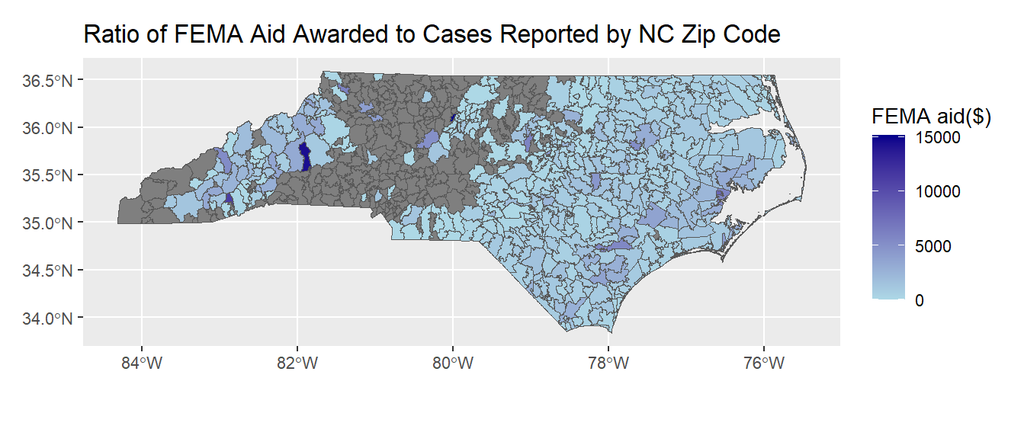

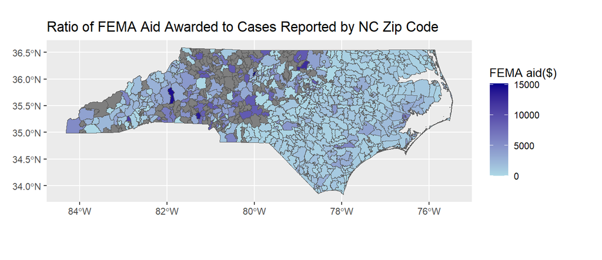